# Geolocating data

Andrew Ba Tran

2018-05-27T21:13:14-05:00

This is from the [fifth chapter](http://learn.r-journalism.com/en/mapping/geolocating/geolocating/) of [learn.r-journalism.com](https://learn.r-journalism.com/).

### Geolocating addresses in R

We’re going to start with geolocating municipal police stations in Connecticut.

We’ll be using the [`ggmap` package](https://github.com/dkahle/ggmap) for a lot of functions, starting with geolocating addresses with Google Maps.

```r
# if you don't have the following packages installed, uncomment and run the lines below

#install.packages(c("dplyr", "ggplot2", "tidyr", "ggmap", "DT", "knitr", "readr"))

library(readr)
library(dplyr)
library(ggplot2)
library(tidyr)
library(ggmap)
library(DT)
library(knitr)
```

```r
stations <- read_csv("data/Police_Departments.csv")
glimpse(stations)
```

```
## Observations: 185
## Variables: 9
## $ NAME        <chr> "AMTRAK POLICE DEPARTMENT", "ANDOVER POLICE DEPART...
## $ DESCRIPTION <chr> "OTHER", "MUNICIPAL", "COLLEGE OR UNIVERSITY", "CO...
## $ TELEPHONE   <chr> "203-773-6000", "860-742-0235", "860-405-9088", "8...
## $ ADDRESS     <chr> "50 UNION AVENUE", "17 SCHOOL ROAD", "1084 SHENNEC...
## $ ADDRESS2    <chr> NA, NA, NA, NA, NA, NA, NA, NA, NA, NA, NA, NA, NA...
## $ CITY        <chr> "NEW HAVEN", "ANDOVER", "GROTON", "HARTFORD", "NEW...
## $ STATE       <chr> "CT", "CT", "CT", "CT", "CT", "CT", "CT", "CT", "C...
## $ ZIP         <int> 6519, 6232, 6340, 6103, 6050, 6410, 6413, 6415, 61...
## $ ZIPP4       <int> 1754, 1526, 6048, 1207, 2439, 2249, 2115, 1230, 16...
```

To find the latitude and longitude of an address, we need a full address like you would put into Google Maps. This data frame has a separate column for each piece of the address.

We need a single column for addresses, so we’ll concatenate *ADDRESS*, *CITY*, *STATE*, and *ZIP*.

```r
stations <- stations %>%
  mutate(ZIP=paste0("0", as.character(ZIP))) %>%
  mutate(location = paste0(ADDRESS, ", ", CITY, ", CT ", ZIP))
```

The function to geocode a single address is `geocode()` but we’ve got a bunch of addresses, so we can use `mutate_geocode()`.

```r
geo <- mutate_geocode(stations, location)
```

```r
# If it's taking too long, you can cancel and load the output by uncommenting the line below
geo <- read_csv("data/geo_stations.csv")

# Bringing over the longitude and latitude data
stations$lon <- geo$lon
stations$lat <- geo$lat
```

This is using Google’s service, and last I checked there were about 2,500 queries allowed per day if you don’t have a key. If you do get a key, check out the documentation at the bottom of [this page](https://github.com/dkahle/ggmap).

**Also** did you know that Google let’s you reverse geocode?

```r
revgeocode(c(lon = -77.030137, lat = 38.902986))
```

```
##   address
## 1      NA
```

### Plotting points with ggplot2

Let’s pull town shapes for Connecticut with **tigris**.

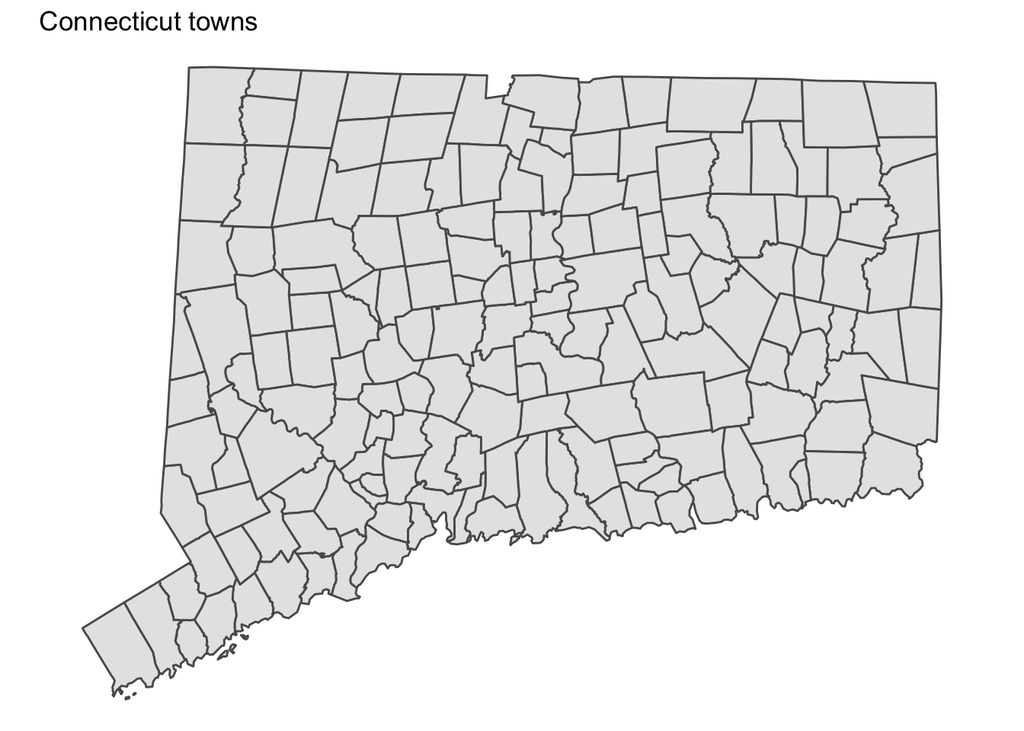

```r
# If you don't have tigris or ggplot2 or sf installed yet, uncomment and run the line below
#install.packages("tigris", "sf", "ggplot2")

library(tigris)
library(sf)
library(ggplot2)

# set sf option

options(tigris_class = "sf")

ct <- county_subdivisions("CT", cb=T)

#If cb is set to TRUE, download a generalized (1:500k) counties file. Defaults to FALSE (the most detailed TIGER file).

ggplot(ct) +
  geom_sf() +
  theme_void() +
  theme(panel.grid.major = element_line(colour = 'transparent')) +
  labs(title="Connecticut towns")
```

Okay, we’ve got the shapefile.

We just add the geolocated points like it was dots on a chart. Because that’s essentially what latitude and longitude is.

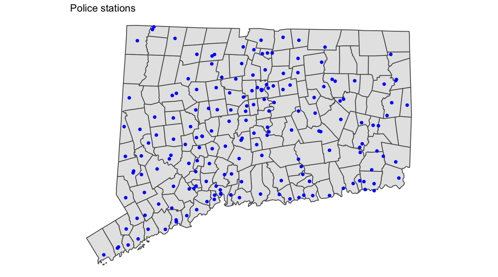

```r
ggplot(ct) +
  geom_sf() +
  geom_point(data=stations, aes(x=lon, y=lat), color="blue") +
  theme_void() +
  theme(panel.grid.major = element_line(colour = 'transparent')) +
  labs(title="Police stations")
```

Alright, I’ll throw in grouping for Description.

And generate some random numbers for staffing for each station so we can make some circle plots.

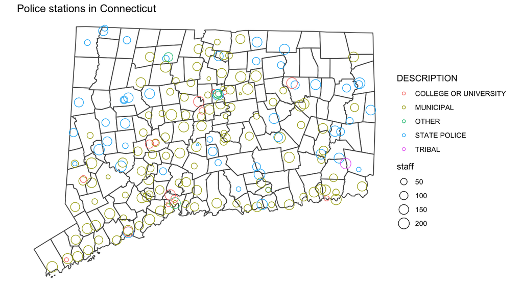

```r
set.seed(7)

stations$staff <- sample(200, size=nrow(stations), replace=T)

ggplot(ct) +
  geom_sf(fill="transparent") +
  geom_point(data=stations, aes(x=lon, y=lat, size=staff, color=DESCRIPTION),  fill="white", shape=1) +
  theme_void() +
  theme(panel.grid.major = element_line(colour = 'transparent')) +
  labs(title="Police stations in Connecticut") +
  coord_sf()
```

I also threw in `coord_sf()` in there at the end. It makes sures that all layer are using a common *CRS*. It sets it based on the first layer.

You can set other projections easily.